# Project - Customer segmentation to analyze usage behavior for potential credit limit enhancement.

The purpose of this project is to identify the right Card Members for a Limit upgradeThe following are the attributes of the dataset CUST_ID : Customer Identification CREDIT_LIMIT : Customer Credit Limit BALANCE : Credit Limit Balance left BALANCE_FREQUENCY : How frequently the Balance is updated (1=frequently,0=not frequently) PURCHASES : Amount of purchases made ONEOFF_PURCHASES : Maximum purchase amount done in one-go INSTALLMENTS_PURCHASES : Amount of purchase done in installment CASH_ADVANCE : Cash in advance taken PURCHASES_FREQUENCY : How frequently the Purchases are made (1=frequently,0=not frequently) ONEOFFPURCHASESFREQUENCY : How frequently Purchases are made in one-go (1=frequently,0=not frequently) PURCHASESINSTALLMENTSFREQUENCY : How frequently purchases in installments are being done (1=frequently,0=not frequently) CASHADVANCEFREQUENCY : How frequently the cash in advance being paid ((1=frequently,0=not frequently) CASHADVANCETRX : Number of Transactions made with "Cash in Advanced" PURCHASES_TRX : Number of purchase transactions made with card PAYMENTS : Amount of Payment paid MINIMUM_PAYMENTS : Minimum amount paid PRCFULLPAYMENT : Percent of full payment paid TENURE : Tenure of credit card service

# 1. Import Libraries and load dataset

```python
%matplotlib inline
import numpy as np  # linear algebra
import pandas as pd # data processing, CSV file I/O (e.g. pd.read_csv)
import seaborn as sns
sns.set(color_codes=True)
import warnings
warnings.filterwarnings('ignore')
import matplotlib.pyplot as plt
from sklearn import preprocessing
from sklearn.model_selection import train_test_split
```

```python
# Load the Credit Card Dataset
credit_df = pd.read_csv("Credit_Card_Data.csv")
```

It is always a good practice to eye-ball raw data to get a feel of the data in terms of number of structure of the file, number of attributes, types of attributes.

```python
credit_df.shape # Rows and Columns are matching
```

```
(8950, 18)
```

Contains 8950 rows with 18 columns. Data is as expected.

# 2. Data Cleaning and Exploration

```python
credit_df.dtypes
```

```
CUST_ID                              object
BALANCE                             float64
BALANCE_FREQUENCY                   float64
PURCHASES                           float64
ONEOFF_PURCHASES                    float64
INSTALLMENTS_PURCHASES              float64
CASH_ADVANCE                        float64
PURCHASES_FREQUENCY                 float64
ONEOFF_PURCHASES_FREQUENCY          float64
PURCHASES_INSTALLMENTS_FREQUENCY    float64
CASH_ADVANCE_FREQUENCY              float64
CASH_ADVANCE_TRX                      int64
PURCHASES_TRX                         int64
CREDIT_LIMIT                        float64
PAYMENTS                            float64
MINIMUM_PAYMENTS                    float64
PRC_FULL_PAYMENT                    float64
TENURE                                int64
dtype: object
```

#### Plot missing values (if any)

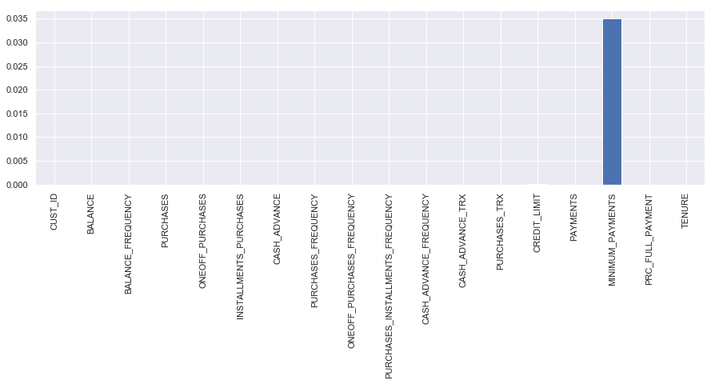

```python
col_null = credit_df.isnull().sum()
col_null_frac = col_null / credit_df.shape[0]

plt.figure(figsize= (15,4))
col_null_frac.plot(kind='bar')
```

```python
credit_df.isnull().sum().sort_values(ascending=False).head()
```

```
MINIMUM_PAYMENTS       313
CREDIT_LIMIT             1
TENURE                   0
PURCHASES_FREQUENCY      0
BALANCE                  0
dtype: int64
```

There are missing values for the attributes "MINIMUM_PAYMENTS" & "CREDIT_LIMIT". Will impute with mean

```python
credit_df['MINIMUM_PAYMENTS'] = credit_df['MINIMUM_PAYMENTS'].fillna((credit_df['MINIMUM_PAYMENTS'].mean()))
credit_df['CREDIT_LIMIT']     = credit_df['CREDIT_LIMIT'].fillna((credit_df['CREDIT_LIMIT'].mean()))
```

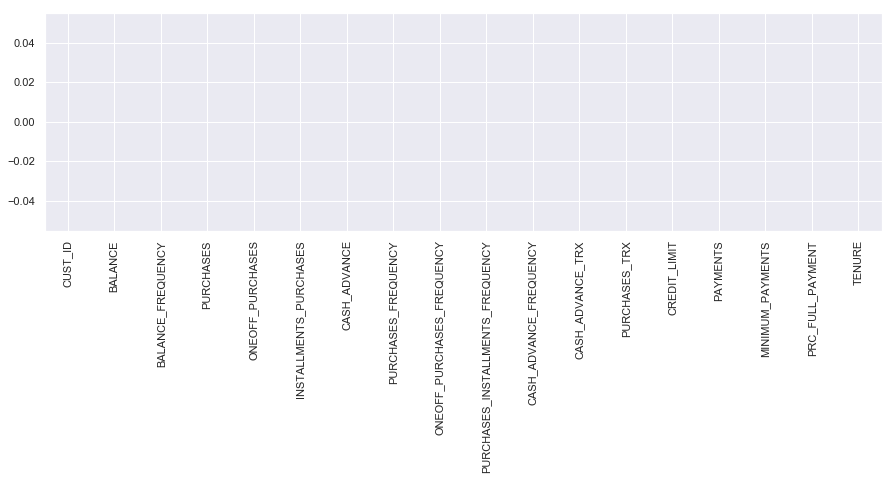

```python
col_null = credit_df.isnull().sum()
col_null_frac = col_null / credit_df.shape[0]

plt.figure(figsize= (15,4))
col_null_frac.plot(kind='bar')
```

Missing values imputed. No more missing values

#### Check for duplicates based on the feature "cid"

```python
print(any(credit_df['CUST_ID'].duplicated()))
```

```
False
```

There are no duplicate rows based on CUST_ID's.

#### Check for zero values (if any)

```python
np.all(credit_df==0)
```

```
False
```

```python
print((credit_df.iloc[:] == 0).sum())
```

```
CUST_ID                                0
BALANCE                               80
BALANCE_FREQUENCY                     80
PURCHASES                           2044
ONEOFF_PURCHASES                    4302
INSTALLMENTS_PURCHASES              3916
CASH_ADVANCE                        4628
PURCHASES_FREQUENCY                 2043
ONEOFF_PURCHASES_FREQUENCY          4302
PURCHASES_INSTALLMENTS_FREQUENCY    3915
CASH_ADVANCE_FREQUENCY              4628
CASH_ADVANCE_TRX                    4628
PURCHASES_TRX                       2044
CREDIT_LIMIT                           0
PAYMENTS                             240
MINIMUM_PAYMENTS                       0
PRC_FULL_PAYMENT                    5903
TENURE                                 0
dtype: int64
```

The features having ZERO values represents valid values. Hence no action is required.

```python
credit_feature_df = credit_df
```

Now it's time to look at the data and see what, if anything, looks weird or notable.

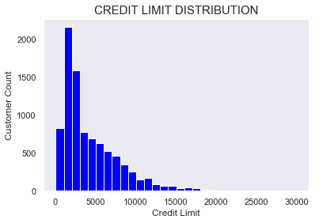

```python
target = credit_feature_df['CREDIT_LIMIT']
fig = plt.figure()
ax = plt.axes()
n,bins,patches=plt.hist(target, 30, facecolor='Blue')
plt.xlabel("Credit Limit")
plt.ylabel("Customer Count")
plt.title("CREDIT LIMIT DISTRIBUTION",fontsize=15)
plt.grid(False)
plt.show()
```

# 3. Descriptive statistics of numeric columns

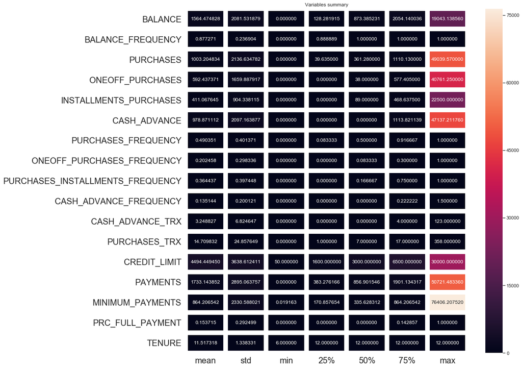

```python
plt.figure(figsize=(15,15))
sns.heatmap(credit_feature_df.describe()[1:].transpose(),linewidth=10,annot=True,fmt="f")
plt.xticks(fontsize=20)
plt.yticks(fontsize=20)
plt.title("Variables summary")
plt.show()
```

```python
credit_feature_df.describe().transpose() # Shows the Stats of only Numerical independent variables
```

|  | count | mean | std | min | 25% | 50% | 75% | max |
| --- | --- | --- | --- | --- | --- | --- | --- | --- |
| BALANCE | 8950.0 | 1564.474828 | 2081.531879 | 0.000000 | 128.281915 | 873.385231 | 2054.140036 | 19043.13856 |
| BALANCE_FREQUENCY | 8950.0 | 0.877271 | 0.236904 | 0.000000 | 0.888889 | 1.000000 | 1.000000 | 1.00000 |
| PURCHASES | 8950.0 | 1003.204834 | 2136.634782 | 0.000000 | 39.635000 | 361.280000 | 1110.130000 | 49039.57000 |
| ONEOFF_PURCHASES | 8950.0 | 592.437371 | 1659.887917 | 0.000000 | 0.000000 | 38.000000 | 577.405000 | 40761.25000 |
| INSTALLMENTS_PURCHASES | 8950.0 | 411.067645 | 904.338115 | 0.000000 | 0.000000 | 89.000000 | 468.637500 | 22500.00000 |
| CASH_ADVANCE | 8950.0 | 978.871112 | 2097.163877 | 0.000000 | 0.000000 | 0.000000 | 1113.821139 | 47137.21176 |
| PURCHASES_FREQUENCY | 8950.0 | 0.490351 | 0.401371 | 0.000000 | 0.083333 | 0.500000 | 0.916667 | 1.00000 |
| ONEOFF_PURCHASES_FREQUENCY | 8950.0 | 0.202458 | 0.298336 | 0.000000 | 0.000000 | 0.083333 | 0.300000 | 1.00000 |
| PURCHASES_INSTALLMENTS_FREQUENCY | 8950.0 | 0.364437 | 0.397448 | 0.000000 | 0.000000 | 0.166667 | 0.750000 | 1.00000 |
| CASH_ADVANCE_FREQUENCY | 8950.0 | 0.135144 | 0.200121 | 0.000000 | 0.000000 | 0.000000 | 0.222222 | 1.50000 |
| CASH_ADVANCE_TRX | 8950.0 | 3.248827 | 6.824647 | 0.000000 | 0.000000 | 0.000000 | 4.000000 | 123.00000 |
| PURCHASES_TRX | 8950.0 | 14.709832 | 24.857649 | 0.000000 | 1.000000 | 7.000000 | 17.000000 | 358.00000 |
| CREDIT_LIMIT | 8950.0 | 4494.449450 | 3638.612411 | 50.000000 | 1600.000000 | 3000.000000 | 6500.000000 | 30000.00000 |
| PAYMENTS | 8950.0 | 1733.143852 | 2895.063757 | 0.000000 | 383.276166 | 856.901546 | 1901.134317 | 50721.48336 |
| MINIMUM_PAYMENTS | 8950.0 | 864.206542 | 2330.588021 | 0.019163 | 170.857654 | 335.628312 | 864.206542 | 76406.20752 |
| PRC_FULL_PAYMENT | 8950.0 | 0.153715 | 0.292499 | 0.000000 | 0.000000 | 0.000000 | 0.142857 | 1.00000 |
| TENURE | 8950.0 | 11.517318 | 1.338331 | 6.000000 | 12.000000 | 12.000000 | 12.000000 | 12.00000 |

Descriptive statistics is meant to know how data is distributed.What does descriptive statistics indicates 1. If mean not equal to Median(Q2) indicates the existance of tail. If mean > median, long tail on right side. Skew on right side. If mean < median, long tail on left side. Skew on left side 2. When we observe difference between (Q1,min) and (Q3,max) is not same data is not symmetric meaning If difference between (Q1,min) > (Q3,max) indicates existance of long skewed tail on left side If difference between (Q1,min) < (Q3,max) indicates existance of long skewed tail on right side 3. When we have longs skews, indicates existance of ourliers.

#### Visualizing the distribution of a dataset. Plot the variables and check for the distributions.

```python
import matplotlib.pyplot as plt
%matplotlib inline
```

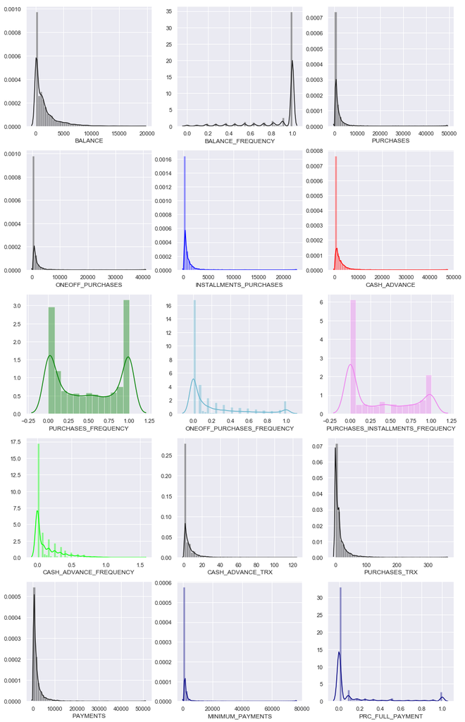

```python
# Plot the distribution

f, axes = plt.subplots(5, 3, figsize=(15, 25))

sns.distplot(credit_feature_df['BALANCE'], color="k", ax=axes[0,0])
sns.distplot(credit_feature_df['BALANCE_FREQUENCY'], color="k", ax=axes[0,1])
sns.distplot(credit_feature_df['PURCHASES'], color="k", ax=axes[0,2])
sns.distplot(credit_feature_df['ONEOFF_PURCHASES'], color="k", ax=axes[1,0])
sns.distplot(credit_feature_df['INSTALLMENTS_PURCHASES'], color="Blue",ax=axes[1,1])
sns.distplot(credit_feature_df['CASH_ADVANCE'], color="red", ax=axes[1,2])
sns.distplot(credit_feature_df['PURCHASES_FREQUENCY'], color="green", ax=axes[2,0])
sns.distplot(credit_feature_df['ONEOFF_PURCHASES_FREQUENCY'], color="c", ax=axes[2,1])
sns.distplot(credit_feature_df['PURCHASES_INSTALLMENTS_FREQUENCY'], color="violet", ax=axes[2,2])
sns.distplot(credit_feature_df['CASH_ADVANCE_FREQUENCY'], color="lime", ax=axes[3,0])
sns.distplot(credit_feature_df['CASH_ADVANCE_TRX'], color="k", ax=axes[3,1])
sns.distplot(credit_feature_df['PURCHASES_TRX'], color="k", ax=axes[3,2])
sns.distplot(credit_feature_df['PAYMENTS'], color="k", ax=axes[4,0])
sns.distplot(credit_feature_df['MINIMUM_PAYMENTS'], color="navy", ax=axes[4,1])
sns.distplot(credit_feature_df['PRC_FULL_PAYMENT'], color="navy", ax=axes[4,2])
plt.show()
```

```python
# Function to determine if the given attribute is positively skewed or negatively skewed

def skew(attribute):

    mean     = round(credit_feature_df[attribute].mean())
    median   = round(credit_feature_df[attribute].median())
    q75, q25 = np.percentile(credit_feature_df[attribute], [75 ,25])

    if  (mean > median):
        print("Positive Right skewed distribution. Median Closure to Q3. Mean > Median")

    if  (mean < median):
        print("Negative Left skewed distribution. Median Closure to Q1. Mean > Median")

    if  (mean == median):
        print("Unskewed distribution. Mean = Median")

    print("Mean   :" ,mean)
    print("Median :" ,median)
    print("25%    :",q25)
    print("75%    :",q75)
    sns.distplot(credit_feature_df[attribute],color="Blue",label='Skew = ' + str(round(credit_feature_df[attribute].skew(),3)))
    plt.legend()
    plt.show()
    return
```

## Objective - Identify Card Members for a Limit upgrade

### High Spending customers

```python
credit_feature_df = credit_df
```

```python
# Function to Show the High Spending Cutomers

def Show(N):

    temp = pd.DataFrame(credit_feature_df.nlargest(N, ['PURCHASES']))

    Cust = list(temp.CUST_ID)
    Pur  = list(temp.PURCHASES)

    plt.figure(figsize=(30,12))
    barWidth = 0.3
    Number = str(N)

    header = 'High Spending ' + Number + ' Customers'
    plt.bar(Cust, Pur,color='Blue',width = barWidth)
    plt.title(header,fontsize=30,weight = 'bold')
    plt.xlabel("Customers",fontsize=25,weight = 'bold')
    plt.ylabel("Amount Spent",fontsize=25,weight = 'bold')
    plt.xticks(fontsize=17,weight = 'bold',rotation=0)
    plt.yticks(fontsize=17)
    plt.grid(False)

    # Text on the top of each barplot
    for i in range(N):
        plt.text(x = Cust[i] , y = Pur[i] +7400 ,s = Pur[i], color = 'Black',size = 20,rotation=90)

    return
```

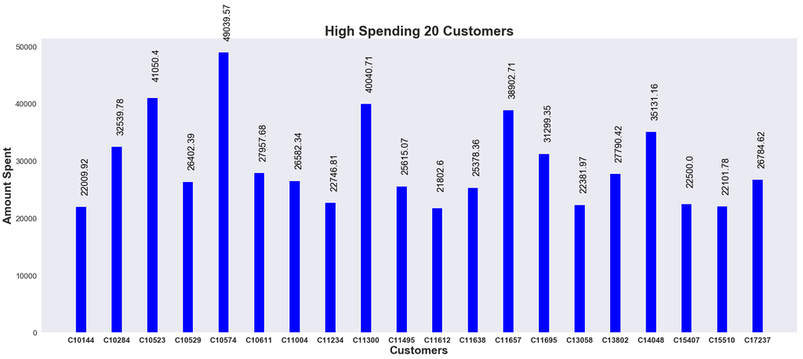

```python
Show(20)
```

### List of 90% Utilization of the Credit Limit

```python
credit_feature_df = credit_df
```

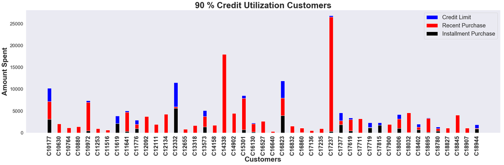

```python
# Filter customers based on
#  - Utilization of Credit Limit is > 90%
#  - Payments > 90% of Credit Limit
#  - ONEOFF_PURCHASES value > 50% of Credit Limit

credit_feature_df['Utilization'] = (((credit_feature_df['CREDIT_LIMIT'] - credit_feature_df['BALANCE'])/credit_feature_df['CREDIT_LIMIT']) * 100)
credit_feature_df = credit_feature_df.loc[(credit_feature_df['Utilization'] > 90.00) & (credit_feature_df['PAYMENTS']>(credit_feature_df['CREDIT_LIMIT']*0.9)) & (credit_feature_df['ONEOFF_PURCHASES']>(credit_feature_df['CREDIT_LIMIT']*0.5))]
Payments_made = list(credit_feature_df['ONEOFF_PURCHASES'])

Cust      = list(credit_feature_df.CUST_ID)
OneOfPur  = list(credit_feature_df.ONEOFF_PURCHASES)
InstlPur  = list(credit_feature_df.INSTALLMENTS_PURCHASES)

plt.figure(figsize=(30,8))
barWidth = 0.4
Number = str(credit_feature_df.shape[0])
header = '90 % Credit Utilization Customers'
plt.bar(Cust, credit_feature_df.PURCHASES,label='Credit Limit',color='Blue',width = barWidth)
plt.bar(Cust, OneOfPur,label = 'Recent Purchase',color='Red',width = barWidth)
plt.bar(Cust, InstlPur,label = 'Installment Purchase',color='Black',width = barWidth)
plt.title(header,fontsize=30,weight = 'bold')
plt.xlabel("Customers",fontsize=25,weight = 'bold')
plt.ylabel("Amount Spent",fontsize=25,weight = 'bold')
plt.xticks(fontsize=20,weight = 'bold',rotation=90)
plt.yticks(fontsize=17)
plt.legend(fontsize=20)
plt.grid(False)
credit_feature_df = credit_feature_df.drop(['Utilization'], axis=1)
credit_df = credit_df.drop(['Utilization'], axis=1)
```

### Dealing with Outliers

Make range to deal with outlier values

```python
del(credit_feature_df)
credit_feature_df = credit_df
```

Outlier presence columns

```python
columns=['BALANCE', 'PURCHASES', 'ONEOFF_PURCHASES', 'INSTALLMENTS_PURCHASES', 'CASH_ADVANCE', 'CREDIT_LIMIT',
        'PAYMENTS', 'MINIMUM_PAYMENTS']

for c in columns:

    Range=c+'_RANGE'
    credit_feature_df[Range]=0
    credit_feature_df.loc[((credit_feature_df[c]>0)&(credit_feature_df[c]<=500)),Range]=1
    credit_feature_df.loc[((credit_feature_df[c]>500)&(credit_feature_df[c]<=1000)),Range]=2
    credit_feature_df.loc[((credit_feature_df[c]>1000)&(credit_feature_df[c]<=3000)),Range]=3
    credit_feature_df.loc[((credit_feature_df[c]>3000)&(credit_feature_df[c]<=5000)),Range]=4
    credit_feature_df.loc[((credit_feature_df[c]>5000)&(credit_feature_df[c]<=10000)),Range]=5
    credit_feature_df.loc[((credit_feature_df[c]>10000)),Range]=6
```

Outlier non-presence columns

```python
columns=['BALANCE_FREQUENCY', 'PURCHASES_FREQUENCY', 'ONEOFF_PURCHASES_FREQUENCY', 'PURCHASES_INSTALLMENTS_FREQUENCY',
         'CASH_ADVANCE_FREQUENCY', 'PRC_FULL_PAYMENT']

for c in columns:
    Range=c+'_RANGE'
    credit_feature_df[Range]=0
    credit_feature_df.loc[((credit_feature_df[c]>0)&(credit_feature_df[c]<=0.1)),Range]=1
    credit_feature_df.loc[((credit_feature_df[c]>0.1)&(credit_feature_df[c]<=0.2)),Range]=2
    credit_feature_df.loc[((credit_feature_df[c]>0.2)&(credit_feature_df[c]<=0.3)),Range]=3
    credit_feature_df.loc[((credit_feature_df[c]>0.3)&(credit_feature_df[c]<=0.4)),Range]=4
    credit_feature_df.loc[((credit_feature_df[c]>0.4)&(credit_feature_df[c]<=0.5)),Range]=5
    credit_feature_df.loc[((credit_feature_df[c]>0.5)&(credit_feature_df[c]<=0.6)),Range]=6
    credit_feature_df.loc[((credit_feature_df[c]>0.6)&(credit_feature_df[c]<=0.7)),Range]=7
    credit_feature_df.loc[((credit_feature_df[c]>0.7)&(credit_feature_df[c]<=0.8)),Range]=8
    credit_feature_df.loc[((credit_feature_df[c]>0.8)&(credit_feature_df[c]<=0.9)),Range]=9
    credit_feature_df.loc[((credit_feature_df[c]>0.9)&(credit_feature_df[c]<=1.0)),Range]=10
```

other columns

```python
columns=['PURCHASES_TRX', 'CASH_ADVANCE_TRX']

for c in columns:

    Range=c+'_RANGE'
    credit_feature_df[Range]=0
    credit_feature_df.loc[((credit_feature_df[c]>0)&(credit_feature_df[c]<=5)),Range]=1
    credit_feature_df.loc[((credit_feature_df[c]>5)&(credit_feature_df[c]<=10)),Range]=2
    credit_feature_df.loc[((credit_feature_df[c]>10)&(credit_feature_df[c]<=15)),Range]=3
    credit_feature_df.loc[((credit_feature_df[c]>15)&(credit_feature_df[c]<=20)),Range]=4
    credit_feature_df.loc[((credit_feature_df[c]>20)&(credit_feature_df[c]<=30)),Range]=5
    credit_feature_df.loc[((credit_feature_df[c]>30)&(credit_feature_df[c]<=50)),Range]=6
    credit_feature_df.loc[((credit_feature_df[c]>50)&(credit_feature_df[c]<=100)),Range]=7
    credit_feature_df.loc[((credit_feature_df[c]>100)),Range]=8
```

```python
credit_feature_df.drop(['CUST_ID','BALANCE','BALANCE_FREQUENCY','PURCHASES','ONEOFF_PURCHASES','INSTALLMENTS_PURCHASES',
                        'CASH_ADVANCE','PURCHASES_FREQUENCY','ONEOFF_PURCHASES_FREQUENCY','PURCHASES_INSTALLMENTS_FREQUENCY',
                        'CASH_ADVANCE_FREQUENCY','CASH_ADVANCE_TRX','PURCHASES_TRX','CREDIT_LIMIT','PAYMENTS',
                        'MINIMUM_PAYMENTS','PRC_FULL_PAYMENT','TENURE'], axis=1, inplace=True)
```

```python
data    = credit_feature_df
```

```python
from sklearn.cluster import KMeans
from sklearn.preprocessing import StandardScaler
scale = StandardScaler()
scaled_data = scale.fit_transform(data)
```

```python
scaled_data.shape
```

```
(8950L, 16L)
```

### Use Elbow method to determine the K Value

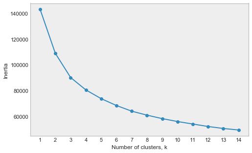

```python
cluster_range = range(1, 15)
cluster_errors = []

for k in cluster_range:
    model     = KMeans(n_clusters=k)
    model.fit(scaled_data)
    labels    = model.labels_
    centroids = model.cluster_centers_
    cluster_errors.append(model.inertia_)  # Cluster errors represents variance between the clusters

plt.figure(figsize=(8,5))
plt.style.use('bmh')
plt.plot(cluster_range, cluster_errors,'-o')
plt.xlabel('Number of clusters, k')
plt.ylabel('Inertia')
plt.xticks(cluster_range)
plt.grid(False)
plt.show()
```

### Create model with k=6

```python
# Number of clusters
kmeans = KMeans(n_clusters=6,random_state=148461)
# Fitting the input data
kmeans = kmeans.fit(scaled_data)
# Getting the cluster labels
labels = kmeans.predict(scaled_data)
# Creating new column "CLUSTER" to hold the cluster id
data["CLUSTER"] = labels
```

### Analyze and Interpret the Clusters

```
Text(0,0.5,u'Customer Count')
```

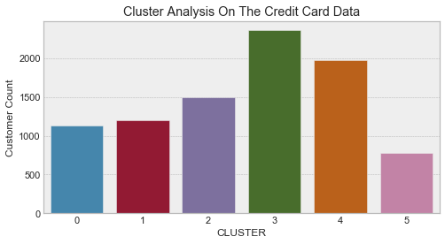

```python
f, (ax1) = plt.subplots(1,1, figsize=(8,4))
sns.countplot(data['CLUSTER'], ax=ax1)
ax1.set_title('Cluster Analysis On The Credit Card Data')
plt.ylabel('Customer Count')
```

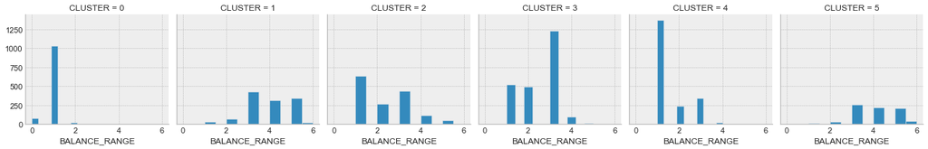

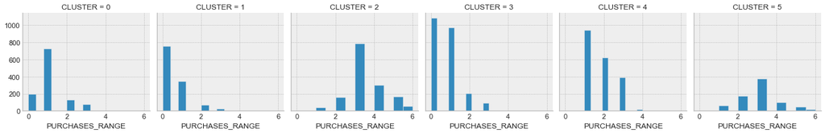

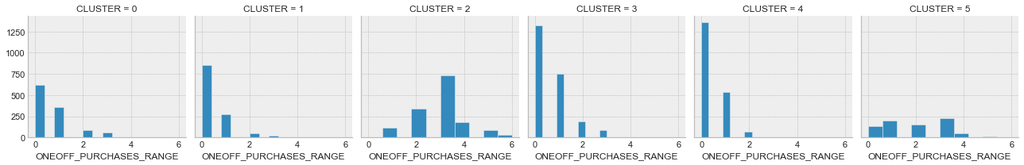

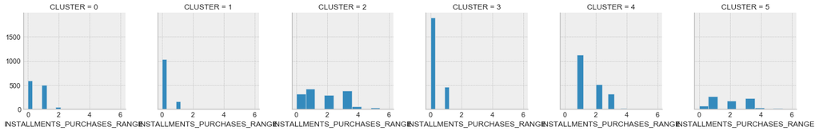

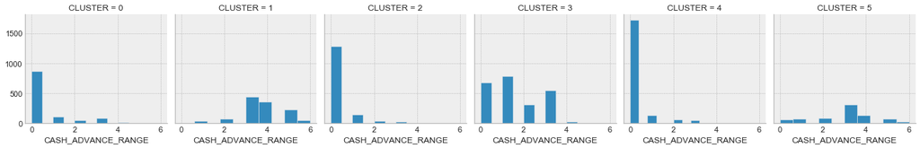

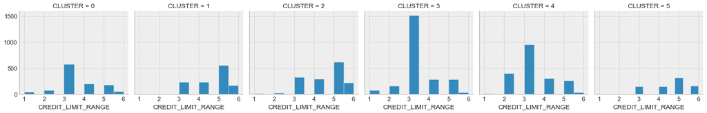

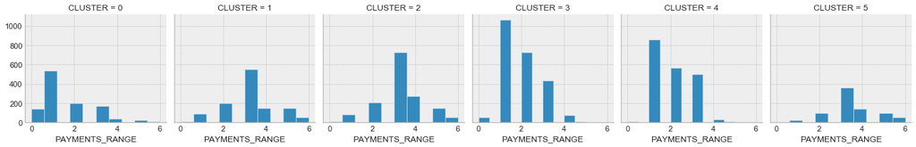

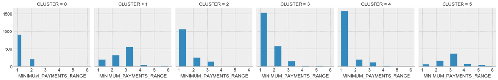

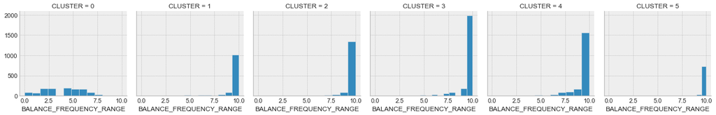

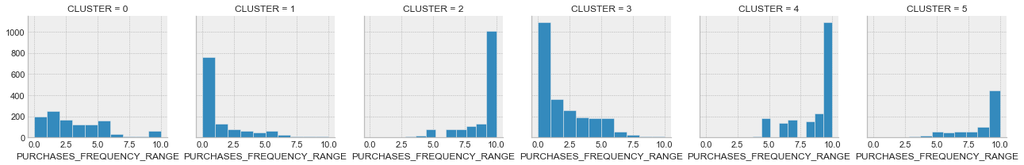

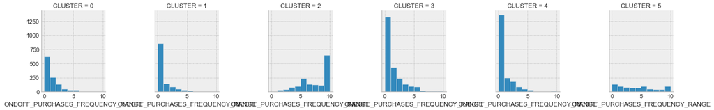

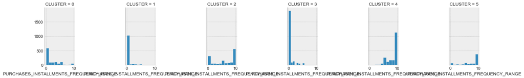

[5 more figures not shown]

```python
plt.figure(figsize=(30,8))
for c in data:
    grid= sns.FacetGrid(data=data,col='CLUSTER')
    grid.map(plt.hist, c)
```